# Lectures on graphical Markov models

Part 1

Author

G. Marchetti

Published

March 21, 2024

# Variables and conditional independencies

## Introduction

Many investigations involve data on many variables measured on each individual under study. One central notion of statistical thinking is the distinction between the association of two variables, considered on an equal standing, and the directed dependence in which one variable is a response and the other is an explanatory variable.

## Notation

Given a system of random variables $\boldsymbol{X} = (X_1, \dots, X_d)$ we denote the joint probability distribution by $p(\boldsymbol{x}) = p(x_1, \dots, x_d)$. We use the same notation for the discrete (pmf) or continuous (pdf) random variables.

We will consider only two fundamental probability distributions for the discrete and continuous cases:

- **Multinomial**: $\boldsymbol{X} \sim$ Multinomial$(1, \boldsymbol{\pi})$
- **Multivariate normal**: $\boldsymbol{X} \sim N(\boldsymbol{\mu}, \Sigma)$

## Discrete data

### Simulation of binary variables in R

Let $X_1, X_2, X_3$ be three binary variables. The joint distribution is defined by a $2^3$ vector of probabilities $\pi$ that sum to 1. The single joint probabilities are all $>0$ (no structural zeros).

````markdown
```{r}
n = 1000
p <- c(0.38, 0.01, 0.07, 0.01, 0.42, 0.02, 0.08, 0.01)
X<- expand.grid(X1 = factor(0:1),
                X2 = factor(0:1),
                X3 = factor(0:1))
Z <- rmultinom(n, size = 1, prob = p)
# X <- X[1:length(p) %*% Z,]
cell <- apply(Z, 2, function(x) which(x==1))
data <- X[cell,]
rownames(data) <- 1:n
```
````

There are 3 types of output: (1) the data matrix, (2) a multidimensional table and (3) an aggregated data matrix as follows.

The data matrix:

````markdown
```{r}
head(X)
tail(X)
```
````

```
  X1 X2 X3
1  0  0  0
2  1  0  0
3  0  1  0
4  1  1  0
5  0  0  1
6  1  0  1
  X1 X2 X3
3  0  1  0
4  1  1  0
5  0  0  1
6  1  0  1
7  0  1  1
8  1  1  1
```

The multidimensional table

````markdown
```{r}
table(X)
```
````

```
, , X3 = 0

   X2
X1  0 1
  0 1 1
  1 1 1

, , X3 = 1

   X2
X1  0 1
  0 1 1
  1 1 1
```

The aggregated data matrix:

````markdown
```{r}
as.data.frame(table(X))
```
````

```
  X1 X2 X3 Freq
1  0  0  0    1
2  1  0  0    1
3  0  1  0    1
4  1  1  0    1
5  0  0  1    1
6  1  0  1    1
7  0  1  1    1
8  1  1  1    1
```

**Example 1** The following data concern a large sample of mothers ($n$ = 24220) on which three binary variables are observed

- $X_1$ perinatal mortality
- $X_2$ previous stillbirth
- $X_3$ skin colour of the mother, considered as a socioeconomic surrogate variable.

$X_1$ is the main response, $X_2$ and $X_3$ are potential explanatory variables.

```
  mortality previous skin-color  Freq
1        no       no         no  9148
2       yes       no         no   270
3        no      yes         no  1678
4       yes      yes         no   134
5        no       no        yes 10502
6       yes       no        yes   371
7        no      yes        yes  1963
8       yes      yes        yes   154
```

We are interested in verifying the dependence of mortality on the skin colour of the mother.

## Continuous variables

### Simulation of Gaussian variables in **R**

Generating a sample with $n = 100$ from a 3-dim Gaussian variable with mean vector zero and a concentration matrix
$$K = \Sigma^{-1}$$
with a zero concentration $\kappa_{13}$

````markdown
```{r}
library(mnormt)
K <- matrix(c(1.2, 0.9,   0,
              0.9, 2.7, 1.4,
              0,   1.4, 1.6),
            3, 3)
dimnames(K) <- list(c("X1","X2", "X3"),
                    c("X1","X2", "X3"))
Sigma <- solve(K)
dimnames(Sigma) <- list(c("X1","X2", "X3"),
                        c("X1","X2", "X3"))
round(Sigma, 2)
round(cov2cor(Sigma),2)
X <- rmnorm(n = 100, varcov = Sigma)
```
````

```
      X1    X2    X3
X1  1.54 -0.94  0.82
X2 -0.94  1.25 -1.09
X3  0.82 -1.09  1.58
      X1    X2    X3
X1  1.00 -0.68  0.53
X2 -0.68  1.00 -0.78
X3  0.53 -0.78  1.00
```

Above you see the covariance and correlation matrices. In the side Figure 1 is shown the scatterplot matrix of the generated data.

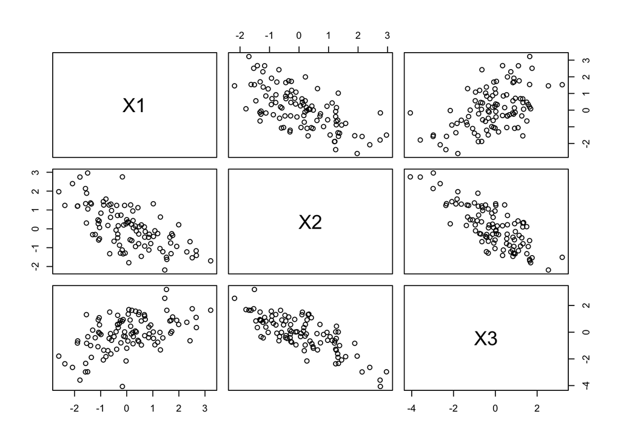

Figure 1: Scatterplot matrix of a trivariate normal sample.

## Conditional independence

Given three random variables (or random vectors) with joint pmf or pdf $p(x_1, x_2, x_3)$ $X_1$ is conditionally independent of $X_2$ given $X_3$, written $X_1 \hspace{0.1em}\perp\hspace{-0.95em}\perp\, X_2 \mid X_3$, if
$$p(x_1, x_2|x_3) = p(x_1|x_3)p(x_2|x_3) \quad \text{ for all } x, y$$
for all $z$ such that $p(z)>0$. Of course conditional independence is symmetric:
$$X_1 \hspace{0.1em}\perp\hspace{-0.95em}\perp\, X_2 \mid X_3 \iff X_2 \hspace{0.1em}\perp\hspace{-0.95em}\perp\, X_1 \mid X_3.$$

### Factorization property

The conditional independence $X_1 \hspace{0.1em}\perp\hspace{-0.95em}\perp\, X_2\mid X_3$ is equivalent to the two factorizations of the joint distribution
$$\begin{aligned}
p(x_1, x_2, x_3) &= p(x_1|x_3) p(x_2|x_3)p(x_3)\\
&= p(x_1|x_3) p(x_3|x_2)p(x_2)
\end{aligned}$$
for all $(x_1, x_2, x_3)$.

### Marginal independence

Marginal independence is a quite different relation: two variables $X_1$ and $X_2$ are marginally independent, denoted by $X_1 \hspace{0.1em}\perp\hspace{-0.95em}\perp\, X_2 \mid \emptyset$ or simply $X_1 \hspace{0.1em}\perp\hspace{-0.95em}\perp\, X_2$, if
$$p(x_1, x_2) = p(x_1) p(x_2)$$
for all pairs $(x_1, x_2)$.

> *Notice that marginal independence $X_1 \hspace{0.1em}\perp\hspace{-0.95em}\perp\, X_2$ does not imply the conditional independence $X_1 \hspace{0.1em}\perp\hspace{-0.95em}\perp\, X_2 \mid X_3$*. The following is a counterexample.

**Example 2** Consider a $2\times 2\times 2$ table classifying 100 subjects convicted of homicide according to the variables `def_race` (defendant’s race), `vict_race` (victim’s race) and `death_pen` (death penalty).

```
  def_race vict_race death_pen Freq
1    white     white        no   37
2    black     white        no    8
3    white     black        no    9
4    black     black        no   38
5    white     white       yes    3
6    black     white       yes    2
7    white     black       yes    1
8    black     black       yes    2
```

The marginal table of defendants’s race and death penalty is

```
        death_pen
def_race no yes
   white 46   4
   black 46   4
```

Thus, there is a marginal independence between defendant’s race and death penalty. However, the conditional distribution is the following:

```
                   death_pen    no   yes
def_race vict_race
white    white               0.925 0.075
         black               0.900 0.100
black    white               0.800 0.200
         black               0.950 0.050
```

and clearly this shows conditional dependence.

### Fundamental property of conditional independence

A fundamental property of conditional independence is the following equivalence
$$X_1 \hspace{0.1em}\perp\hspace{-0.95em}\perp\, (X_2, X_3) \mid X_4 \iff X_1 \hspace{0.1em}\perp\hspace{-0.95em}\perp\, X_2 \mid X_4 \quad \text{and} \quad
X_1 \hspace{0.1em}\perp\hspace{-0.95em}\perp\, X_3 \mid (X_2, X_4).$$
This property makes it possible to decompose a CI involving random vectors into a set of pairwise conditional independencies.

This property is said to obey to the so-called *semi-graphoid axioms* ; see Pearl (1988).

Pearl, Judea. 1988. *Probabilistic Reasoning in Intelligent Systems: Networks of Plausible Inference*. San Mateo, CA: Morgan Kaufmann.

In distributions that are *strictly positive* an additional property called the **intersection property** holds:
$$X_1 \hspace{0.1em}\perp\hspace{-0.95em}\perp\, X_2 \mid (X_3,X_4) \quad \& \quad X_1 \hspace{0.1em}\perp\hspace{-0.95em}\perp\, X_3 \mid (X_2, X_4) \implies X_1 \hspace{0.1em}\perp\hspace{-0.95em}\perp\, (X_2, X_3) \mid X_4.$$

### Composition property

There is a further property of CI called the **composition property** that seems quite natural:
$$X_1 \hspace{0.1em}\perp\hspace{-0.95em}\perp\, X_2 \mid X_4 \quad \& \quad X_1 \hspace{0.1em}\perp\hspace{-0.95em}\perp\, X_3\mid X_4 \implies X_1 \hspace{0.1em}\perp\hspace{-0.95em}\perp\, (X_2, X_3) \mid X_4.$$
This property holds for the family of the multivariate normal distributions. Considering the simplest case when the variable $X_4$, assume that
$$(X_1, X_2, X_3)^T \sim N(\boldsymbol{\mu }, \Sigma) \text{ with }
\Sigma = \begin{pmatrix}
\sigma_{11} & 0 & 0 \\
. & \sigma_{22} & \sigma_{23} \\
. & . & \sigma_{33}
\end{pmatrix}.$$
Then it can be shown that $\sigma_{12} = 0$ and $\sigma_{13} = 0$ are equivalent to $X_1 \hspace{0.1em}\perp\hspace{-0.95em}\perp\, X_2 \quad \& \quad X_1 \hspace{0.1em}\perp\hspace{-0.95em}\perp\, X_3$. But therefore, the joint density can be decomposed as $p(x_1, x_2, x_3) = p(x_1) p(x_2, x_3)$ implying the joint independence $X_1 \hspace{0.1em}\perp\hspace{-0.95em}\perp\, (X_2, X_3)$.

Nevertheless this property does not hold for all distributions. Below, you see a counterexample still for three binary variables.

**Example 3**

```
     X3_X2
X1     0_0  0_1  1_0  1_1 Sum
  0   0.20 0.05 0.05 0.20 0.5
  1   0.15 0.10 0.10 0.15 0.5
  Sum 0.35 0.15 0.15 0.35 1.0
```

This $2\times 2\times 2$ table implies two marginal tables with independence (actually they have uniform probability)

```
   X2
X1     0    1
  0 0.25 0.25
  1 0.25 0.25
   X3
X1     0    1
  0 0.25 0.25
  1 0.25 0.25
```

but it can verified that $p(x_1, x_2, x_3) \ne p(x_1)p(x_2, x_3)$.

# Graphs representing conditional independencies

In general a graph is a pair of sets $G = (V, E)$ where $V = \{1, \dots, d = |V|\}$ is a set of *nodes/vertices* and $E$ is a set of *edges* connecting two nodes $i$ and $j$. The edges can be

- *arrows*: $i \rightarrow j$
- *full lines*: $i -\!\!\!- j$
- *arcs*: $i \longleftrightarrow j$

> The arcs are bi-directed edges which I will represent as dashed arcs to better distinguish them from arrows

We consider tipically graphs with at most one edge between two nodes, but there are exceptions. We distiguish several types of graph:

- **directed graphs** containing only arrows
- **undirected graphs** containing only full lines
- **bi-directed graphs** containing only arcs.
- **mixed graphs** containing the above three types of edges.

Some examples are shown in Figure 2.

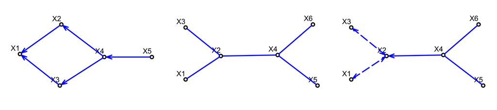

Figure 2: Left: a directed graph. Center: an undirected graph. Right: a mixed graph.

### Why graphs?

Probabilistic graphical models are introduced to represent a set of conditional independence relationships between the variables. The method consists of defining as many nodes as there are variables by indicating with edges the dependencies between variables. Missing edges, on the other hand, define the conditional independencies between variables with a conditioning set determined by the structure of the graph.

To understand how, it is useful to start from a characterization of the variables that are modelled. Typically an investigation is based on $n$ observations collected on variables that may be distinguished as

- *purely explanatory*, (background) variables
- *intermediate variables*
- *response variables*

**Example 4** Consider a study on labor market where 3 binary variables are observed: `Hiring`: the successful job placement of an individual (Yes=1, No=0), `Qualification`: the university studies of the applicant (Classical, Scientific), and the `Gender` of the applicant (F = female, M = male).

It seems natural to predict hiring (`H`) from both qualification (`Q`) and gender (`G`). Thus `H` is the *primary response*, and `G` is a *purely explanatory variable* (that in principle cannot be considered a *treatment*). On the other hand it is reasonable to consider `Q` to be dependent on gender `G` but a potential influence of hiring `G`. Thus qualification is called an *intermediate variable*.

The three variables, by subject-matter considerations, follow the order $\texttt{H} < \texttt{Q} < \texttt{G}$ and in order to respect the interpretation, the joint distribution should be factorized as
$$P(\texttt{H} = i, \texttt{Q} = j, \texttt{G} = k) =
P(\texttt{H} = i \mid \texttt{Q} = j, \texttt{G} = k)
P(\texttt{Q} = j\mid \texttt{G} = k) P(\texttt{G} = k)$$
The dependencies in the joint distribution are compactly expressed bu the directed graph in Figure 3.

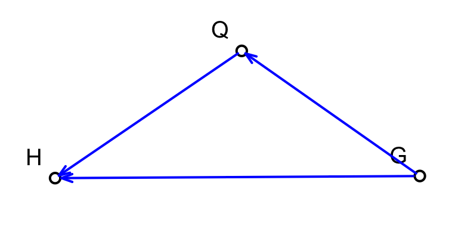

Figure 3: The directed graph associated to the distribution of `H` = hiring, `Q` = qualification and `G` = gender.

Each arrow is directed from the explanatory variables to the response or the intermediate variable and represents the dependence specified by the factors as follows
$$\begin{aligned}
\texttt{H} \leftarrow \texttt{Q}, \texttt{H} \leftarrow \texttt{G}
&: P(\texttt{H} = i \mid \texttt{Q} = j, \texttt{G} = k)\\
\texttt{Q} \leftarrow \texttt{G} &: P(\texttt{Q} = j\mid \texttt{G} = k)
\end{aligned}$$
Now suppose that hiring `H` depends only on qualification `Q`. This implies that the first factor can be simplified
$$P(\texttt{H} = i \mid \texttt{Q} = j, \texttt{G} = k) =
P(\texttt{H} = i \mid \texttt{Q} = j)$$
and there is a conditional independence $\texttt{H} \hspace{0.1em}\perp\hspace{-0.95em}\perp\, \texttt{G} \mid \texttt{Q}$ that can be expressed by deleting the edge $\texttt{H} \leftarrow \texttt{G}$ as shown in Figure 4.

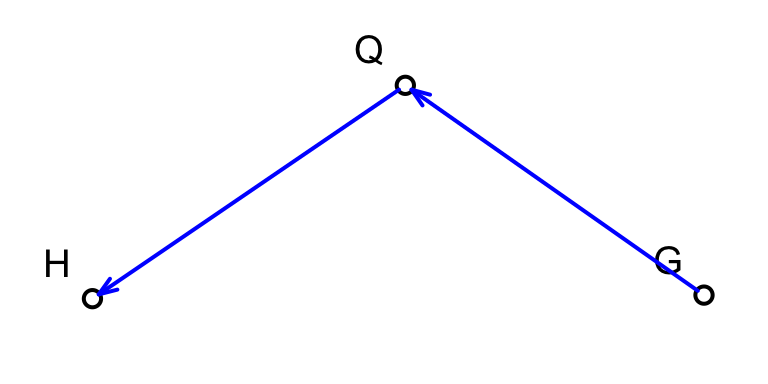

Figure 4: The directed graph associated to the distribution of `H` = hiring, `Q` = qualification and `G` = gender, showing the conditional independence of `H` and `G` given `Q`.

## Directed Acyclic Graphs

The graph in the previous example is a special case of directed acyclic graph (DAG). This kinds of graph are quite useful to deal with asymmetric relationships between variables. The directed acyclic graph models, sometimes called *Bayesian networks* are directed graphs with *no directed cycles*.

This means that in such graphs it is not possible to start from any node and reach the same node by following the direction of the arrows. For instance, if in the graph of Figure 4 we add an edge $\texttt{H} \rightarrow \texttt{G}$ we obtain a directed cycle that is forbidden in DAGs.

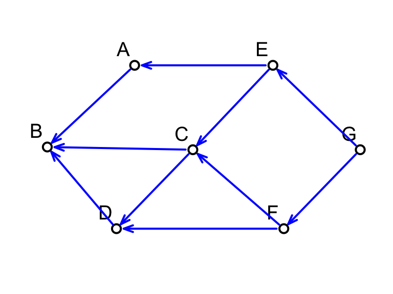

Figure 5: A directed acyclic graph with $7$ nodes.

An example of a more general DAG is shown in Figure 5 where the nodes are denoted by capital letters and should be interpreted as variables. A DAG is defined essentially by the set of **parents** of each node, that is by the set of nodes that are directly connected to each node. In the graph of Figure 5 we have for example
$$\begin{array}{cc}
\text{node} & \text{pa}(\text{node}) \\ \hline
B & A, D, C \\
A & E\\
D & C, F\\
C & E, F\\
E & G\\
F & G\\
G & \emptyset\\ \hline
\end{array}$$
Note that the set of parents can be empty.

The nodes of a DAG can always be well-ordered, that is we can assign to each node a number so that for each arrow the head number is always smaller than the tail number. For instance the graph of Figure 5 is well-ordered if the nodes are listed as
$$B, A, D, C, E, F, G$$
Notice that this order is not unique because
$$B, D, C, A, F, E, G$$
is also another possible well-ordering.

If the DAG is well-ordered we can define for each node the set of its *predecessors* containing the nodes that have a higher number than that of the node. For instance, in the first well-ordering
$$\text{pre}(D) = \{C,E,F,G\}.$$

### Factorization

> *It can be proved that the distribution is Markov to $G$ if and only if the following **ordered Markov property holds***:
> $$X_i \hspace{0.1em}\perp\hspace{-0.95em}\perp\, X_{\text{pre}(i) \setminus \text{pa}(i)} \mid X_{\text{pa}(u)}$$

This theorem implies that the joint distribution that is Markov to a DAG must satisfy a set of conditional independencies: each node of the DAG is independent of all the variables that are predecessors but not parents, given its parents.

For the DAG of Figure 5 we have
$$\begin{array}{ccc}
\text{node} & \text{pre}(\text{node}) \setminus \text{pa}(\text{node}) & \text{pa}(\text{node}) \\ \hline
B & E,F,G & A,D,C \\
A & D,C,F,G & E\\
D & E,G & C, F\\
C & G & E,F \\
E & F & G \\ \hline
\end{array}$$

## Significance tests for CI

We are interested in testing the CI hypothesis
$$X_i \hspace{0.1em}\perp\hspace{-0.95em}\perp\, X_{b} \mid X_{c} \quad \text{ for } i = 1 \dots, d$$
with $c = \text{pa}(i)$ and $b = \text{pre}(i) \setminus \text{pa}(i)$. We use the likelihood ratio test defined for the Gaussian and the Multinomial cases as follows.

- **Gaussian case**
  $$\text{dev}_i = -n \log(\det S \hat K)$$
  where $S$ is the sample covariance matrix for the variables $X_i, X_{b}, X_{c}$ and $\hat K$ is the inverse of the matrix
  $$\hat S = S_{ic}S_{cc}^{-1} S_{cb}.$$
  The deviance has an asymptotic chi-squared distribution with $|i| |b|$ degrees of freedom.
- **Multinomial case**
  $$\text{dev}_i = \sum_{s\in \mathcal{I}}\sum_{t \in \mathcal{B}}\sum_{u \in \mathcal{C}} \frac{n_{stu}}{n} \log \frac{n_{stu}n_{++u}}{n_{s+u}n_{+tu}}$$
  where $n_{stu}$ are the joint frequencies of the contingency table with levels $\mathcal{I} \times \mathcal{B} \times\mathcal{C}$ corresponding to the random variables (or vectors) $X_i$, $X_b$, $X_c$. We make use of the subscript “+” to denote the marginal frequencies. The deviance has an asymptotic chi-squared distribution with $(|\mathcal{I}| - 1)(|\mathcal{B}|-1) |\mathcal{C}|$ degrees of freedom.

**Example 5** To test the independence of mortality and skin color given the previous still-birth we can use the function `ci.test` in package **bnlearn**. Start from the aggregate table and transform it to a data frame.

````markdown
```{r}
counts <- c(9148, 270, 1678, 134, 10502, 371, 1963, 154)
X <- expand.grid(X1 = factor(c("no", "yes")),
                 X2 = factor(c("no", "yes")),
                 X3 = factor(c("no", "yes")))
colnames(X) <- c("mortality", "previous", "skin_color")
X$Freq <- counts
X
```
````

```
  mortality previous skin_color  Freq
1        no       no         no  9148
2       yes       no         no   270
3        no      yes         no  1678
4       yes      yes         no   134
5        no       no        yes 10502
6       yes       no        yes   371
7        no      yes        yes  1963
8       yes      yes        yes   154
```

Then, the deviance (called `mi`), the degrees of freedom and the p-values are calculated with

````markdown
```{r}
ci.test("mortality", "skin_color", "previous", data = tab2data(X))
```
````

```
    Mutual Information (disc.)

data:  mortality ~ skin_color | previous
mi = 4.9513, df = 2, p-value = 0.08411
alternative hypothesis: true value is greater than 0
```

$$\begin{array}{lrrrrrr}
& region &Atlantic & BC & Ontario & Prairie & Quebec\\ \hline
children & hincome & & & & & \\
absent & 0 & 2 & 6 & 16 & 2 & 8 \\
& 1 & 2 & 8 & 17 & 3 & 15\\
present & 0 & 13 & 9 & 46 & 7 & 20\\
& 1 & 13 & 6 & 29 & 19 & 22\\ \hline
\end{array}$$